# Black Thrive Shared Measurement System Haringey

November 2021

[figure not shown]

# Overview

This document presents the findings for the first version of Black Thrive Global’s Shared Measurement System dashboard for Haringey. The aim of the dashboard is to quantify racial inequality in Haringey by comparing various indicators for the Black population with the White population. Doing so makes it possible to identify the aspects of life in Haringey where inequality is manifest and to highlight where change is needed. By routinely reassessing these indicators, it will also be possible to track if and how these inequalities change over time.

The indicators included in this dashboard were selected because they are the ones currently presented in Black Thrive’s [Lambeth dashboard](https://lambeth.blackthrive.org/shared-measurement-system/). The indicators are:

- Number of children reaching a Good Level of Development at age 5
- Number of pupils achieving Level 4 or above in GCSE Maths and English
- Number of children looked after by the local authority
- Number of 16-64 year olds in employment
- Number of individuals subjected to Police Stop and Search
- Number of households identified as homeless or in need of assistance to prevent becoming homeless

Note that it has not yet been possible to acquire the data for the three Lambeth indicators relating to mental health outcomes:

- Rate of Section 136 detentions
- Rate of episodes of physical restraint on wards
- Percentage of people who are moderately or severely depressed prior to starting treatment with Talking Therapies

The data sources for the indicators analysed in this report are provided in the Appendix.

# Procedure and Results

The data were analysed to determine whether the likelihood of each indicator outcome differed for Black versus White individuals. From this analysis is it possible to produce a relative risk ratio, which describes how much more or less likely an outcome is for the Black population compared to the White population. A ratio of exactly 1 indicates that the likelihood of the outcome is the same for both the Black population and the White population. A ratio of less than 1 indicates that the outcome is *less likely* for the Black population compared to the White population, and a ratio of more than 1 indicates the outcome is *more likely* for the Black population compared to the White population.

The plot below makes the results straightforward to interpret. Points to the left of the orange line indicate outcomes that are *less likely* for the Black population compared to the White population. Points to the right of the orange line indicate outcomes that are *more likely* for the Black population compared to the White population. Points that are close to the orange line (where the black bar coming from the point touches the orange line) indicate outcomes that are *just as likely* for the Black population as they are for the White population.

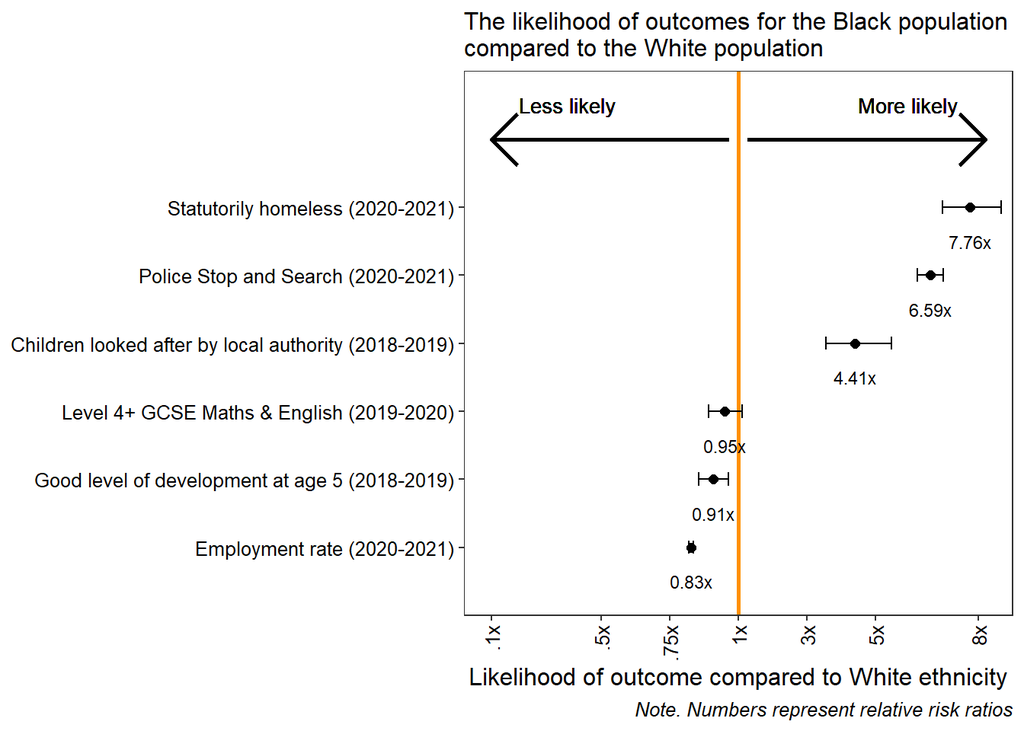

To summarise the results:

- Black 16-64 year olds were 17.18% less likely than White 16-64 year olds to be in employment.
- Black children were 9.15% less likely than White children to reach a Good Level of Development at age 5.
- Black pupils were just as likely as White pupils to achieve at least Level 4 in GCSE Maths and English.
- Black children were 341% (i.e., 4.41 times) more likely than White children to be looked after the local authority.
- Black individuals were 559% (i.e., 6.59 times) more likely than White individuals to be stopped and searched by Police.
- Black households were 676% (i.e., 7.76 times) more likely than White households to be statutorily homeless or at risk of becoming homeless.

## Indicator breakdowns

The above results are broken down below. For each indicator, the number of individuals of each ethnicity is plotted. A percentage is also presented, which represents the number as a proportion of the total population of each ethnicity.

### Employment

The employment rate for Black 16-64 year olds in Haringey from April 2020 to March 2021 was 64.04%, compared to 77.32% for White 16-64 year olds. Black 16-64 year olds were 17.18% less likely than White 16-64 year olds to be in employment.

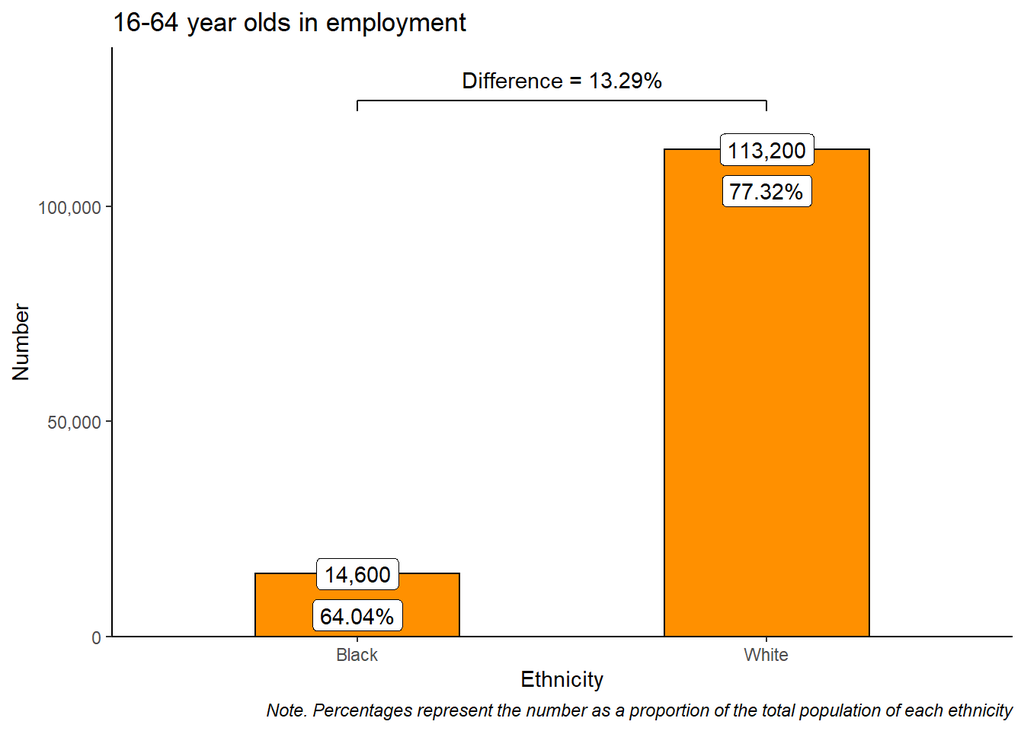

### Children reaching good level of development at age 5

In the 2018-2019 academic year, 70.02% of Black children, compared to 77.07% of White children, were assessed as reaching a Good Level of Development at age 5. Black children were 9.15% less likely than White children to reach a Good Level of Development at age 5.

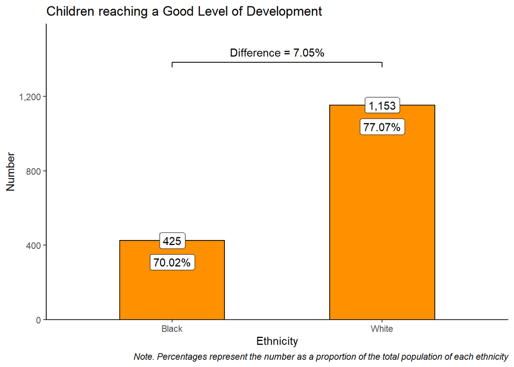

### Pupils achieving Level 4+ in GCSE Maths and English

In the academic year 2019-2020, 68.9% Black pupils and 72.4% of White pupils achieved at least Level 4 in GCSE Maths and English. This difference was not statistically significant.

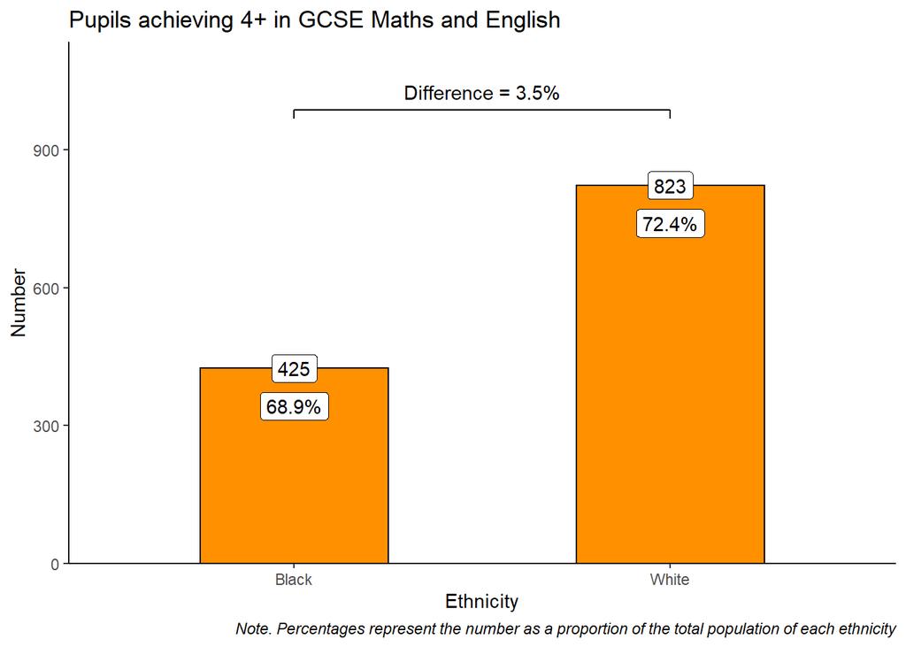

### Children looked after by the local authority

In the 2018-2019 financial year, 1.73% of Black children, compared to 0.39% of White children, were looked after by the local authority. Black children were 341% (i.e., 4.41 times) more likely than White children to be looked after the local authority.

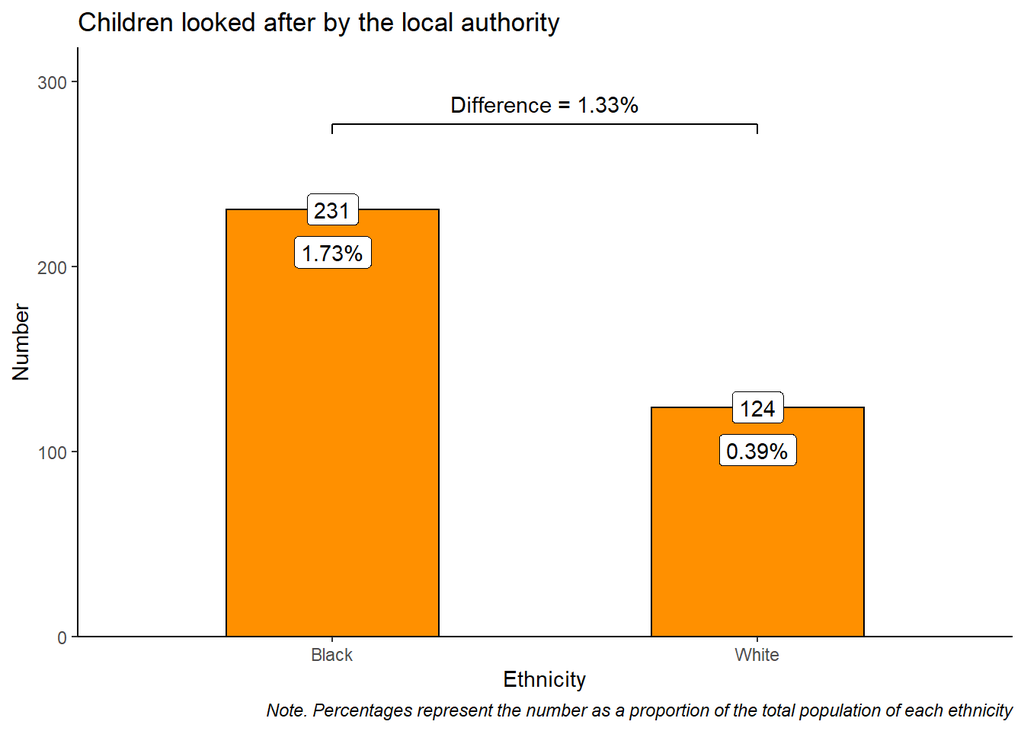

### Individuals subject to Police Stop and Search

From September 2020 to August 2021, 8.04% of Black individuals, compared to 1.22% of White individuals, were subject to Police Stop and Search in Haringey. Black individuals were 559% (i.e., 6.59 times) more likely than White individuals to be stopped and searched by Police.

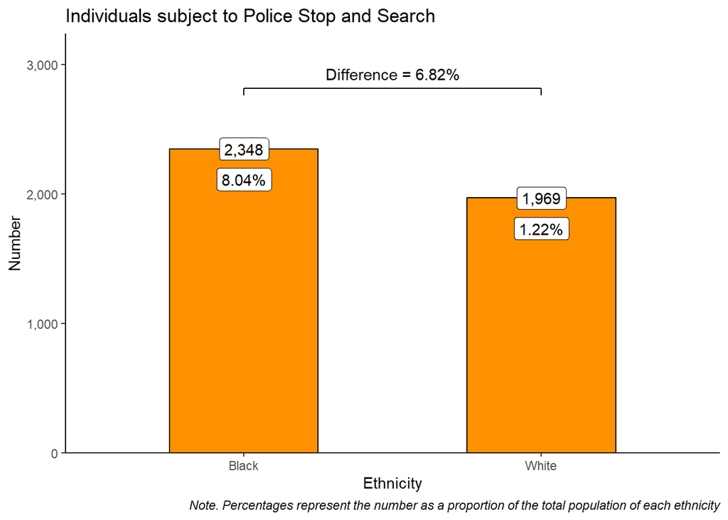

### Households identified as homeless or at risk of being homeless

In the 2020-2021 financial year, 2.59% of Black households, compared to 0.33% of White households, were identified as in need of assistance (i.e., owed prevention or relief duty) because they were either homeless or at risk of becoming homeless. Black households were 676% (i.e., 7.76 times) more likely than White households to be statutorily homeless or at risk of becoming homeless.

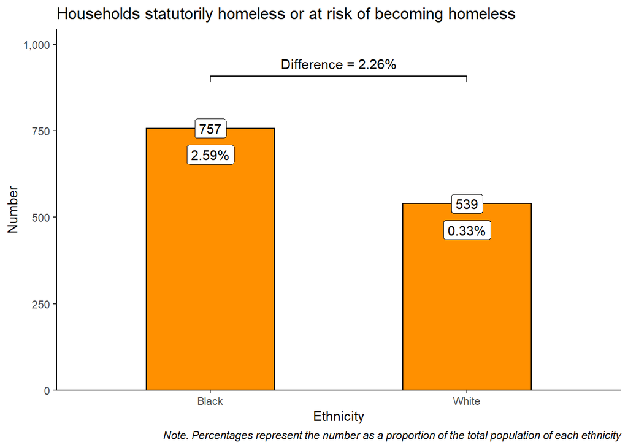

# Authors

This document was produced by the Research Team at Black Thrive Global:

**Jolyon Miles-Wilson**

**Dr Celestin Okoroji**

Any questions, comments, and/or feedback on any aspect of this report are greatly appreciated. Please contact us at research@blackthrive.org, FAO Jolyon Miles-Wilson.

# Supporting information

The R code that produced this report is available on Github [here](https://github.com/BlackThrive/haringey_sms). A separate methodology paper that provides more detail on the data and analysis procedure is available [here](https://github.com/BlackThrive/sms_methodology).

# Appendix

| Indicator | Date | Source |
| --- | --- | --- |
| Good level of development | 2018-2019 academic year | [Early Years Foundation Stage Profile results](https://www.gov.uk/government/statistics/early-years-foundation-stage-profile-results-2018-to-2019) |
| Level 4+ GCSE Maths & English | 2019-2020 academic year | [Key Stage 4 performance](https://explore-education-statistics.service.gov.uk/find-statistics/key-stage-4-performance-revised#dataDownloads-1) |
| Children looked after by local authority | 2018-2019 financial year | [Children looked after in England including adoption](https://www.gov.uk/government/statistics/children-looked-after-in-england-including-adoption-2018-to-2019) |
| 16-64 year olds in employment | 12 months to March 2021 | [NOMIS Annual Population Survey](https://www.nomisweb.co.uk/datasets/apsnew) |
| Individuals subject to Stop and Search: Haringey | 12 months to August 2021 | [Metropolitan Police Stop and Search Dashboard Data](https://data.london.gov.uk/dataset/mps-stop-and-search-public-dashboard-data) |
| Homeless or at risk of becoming homeless | 2020-2021 financial year | [Live tables on homelessness; Detailed local authority level tables](https://www.gov.uk/government/statistical-data-sets/live-tables-on-homelessness#homelessness-summary-local-authority-level-tables) |
| Adult population | 2021 | [Annual Population Survey](https://www.nomisweb.co.uk/datasets/apsnew) |
| Child population: Haringey | 2019 | [Greater London Authority Ethnic group population projections](https://data.london.gov.uk/dataset/ethnic-group-population-projections) |